# Car Adverts

Spiridon Zarkov

2017-07-17

One month of data has been gathered about car ads. Now the team is focused on brining buyers and sellers together to make a great deal. Sellers place ads, and buyers look for these ads by browsing or searching on the site. When a buyer finds an ad they find interesting in the result list and clicks it, we call this a ‘View Item page’- a VIP view. When a buyer proceeds to contact a seller to get more info or strike a deal, we call this a lead. They can do so by calling (Phone click), asking a question over email (ASQ: ask seller Question), clicking out to a seller’s website (URL_CLICK) or placing a bid.

Lets see what we can infer from this data and what type of predictive model we will be able to build.

Metadata:

- src_ad_id: id of ad
- telclicks: number of phone clicks
- bids: number of bids
- carrosserie: vehicle type
- photo_cnt: number of photos
- aantaldeuren: number of doors
- n_asq: number of emails sent to seller
- bouwjaar: year the car was built
- emmisie: emissions
- energielabel: energy label
- brand: brand of car
- ad_start_dt: ad start date
- vermogen: horsepower
- webclicks: number of clicks to sellers website
- model: model of the car
- aantalstoelen: number of seats
- price: price tag
- test group: whether car was in test group “A”, “B”, or no test group

Lets begin by reading in and examining our data

```r
## Importing the Data
# Setup how the classes will be read in
class <- c("numeric", "numeric", "numeric", "character", "character", "numeric",
           "numeric", "numeric", "factor", "numeric", "character", "numeric",
           "factor", "factor", "numeric", "character", "numeric", "numeric",
           "character", "character", "numeric", "factor", "character")

path <- c("./input/cars_dataset.csv")

# Read in and examine the data
cars <- data.table::fread(path, colClasses = class)
```

```r
# Summary Statistics
str(cars)
```

```
## Classes 'data.table' and 'data.frame':   183062 obs. of  23 variables:
##  $ src_ad_id    : num  1.01e+09 1.11e+09 1.04e+09 1.08e+09 1.18e+09 ...
##  $ telclicks    : num  0 0 0 0 0 0 0 110 0 0 ...
##  $ bids         : num  0 20 6 14 12 13 8 0 2 5 ...
##  $ kleur        : chr  "Wit" "Zwart" "Wit" "Zwart" ...
##  $ carrosserie  : chr  "Terreinwagen" "?" "Hatchback (3/5-deurs)" "Hatchback (3/5-deurs)" ...
##  $ kmstand      : num  90800 335000 53619 175000 150000 ...
##  $ days_live    : num  100 14 27 3 3 1 1 30 0 1 ...
##  $ photo_cnt    : num  8 8 14 11 5 5 12 4 6 2 ...
##  $ aantaldeuren : Factor w/ 10 levels "0","1","2","3",..: 6 10 4 4 6 6 5 5 6 6 ...
##  $ n_asq        : num  282 147 130 125 114 107 96 93 91 89 ...
##  $ bouwjaar     : chr  "2011" "2011" "2009" "2001" ...
##  $ emissie      : chr  "135" "89" "110" "149" ...
##  $ energielabel : Factor w/ 8 levels "?","A","B","C",..: 3 2 2 4 3 3 1 5 2 4 ...
##  $ brand        : Factor w/ 192 levels "ACKERMANN-FRUEHAUF",..: 133 188 60 145 143 60 173 13 35 21 ...
##  $ l2           : chr  "134" "157" "111" "140" ...
##  $ ad_start_dt  : chr  "11/13/2016" "11/18/2016" "11/5/2016" "11/1/2016" ...
##  $ vermogen     : num  86 55 51 55 66 44 155 103 50 120 ...
##  $ webclicks    : num  0 0 0 0 0 0 0 0 0 0 ...
##  $ model        : chr  "ASX" "POLO" "500" "206" ...
##  $ aantalstoelen: chr  "5" "5" "4" "5" ...
##  $ price        : num  89000 45000 54990 7500 40000 ...
##  $ test group   : Factor w/ 3 levels "","a","b": 2 2 1 3 2 3 3 2 3 2 ...
##  $ V23          : chr  "" "" "" "" ...
##  - attr(*, ".internal.selfref")=<externalptr>
```

```r
# Dimensions
dim(cars)
```

```
## [1] 183062     23
```

```r
# clean the test group and check data
cars$test_group_clean <- factor(ifelse(cars$`test group` == "a", "A",
                                ifelse(cars$`test group` == "b", "B",
                                "Missing")))
# Most of the data is missing
# Assumption for missing data is to get an accurate statistical significance
# as a very large sample size can achieve statistical significane without relevance
# Not a useful variable unless we examining the A/B Test Results
table(cars$test_group_clean)
```

```
##
##       A       B Missing
##    1803    1831  179428
```

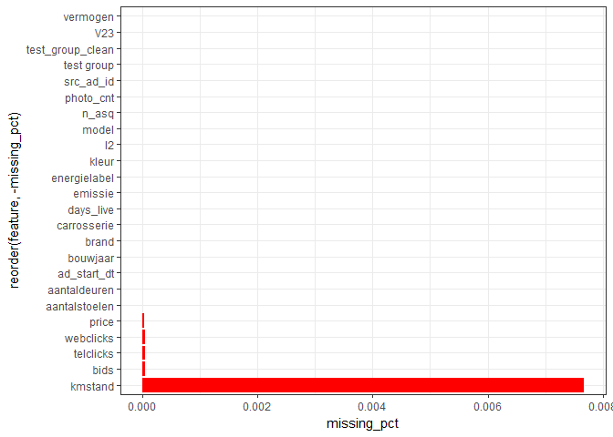

```r
# Lets explore the data further
# How much data is missing?
missing_values <- cars %>% summarise_all(funs(sum(is.na(.))/n()))
missing_values <- gather(missing_values, key = "feature", value = "missing_pct")
missing_values %>%
  ggplot(aes(x = reorder(feature, - missing_pct), y = missing_pct)) +
  geom_bar(stat = "identity", fill = "red") +
  coord_flip() + theme_bw()
```

```r
# A very small percentage of data is NA
# We will likely not need to do any KNN/RF imputations
```

```r
# Examine the Bouwjaar Feature
# Year 2000 needs to be cleaned
table(cars$bouwjaar)
```

```
##
##     1991     1992     1993     1994     1995     1996     1997     1998
##      149      325      374      633      904     1573     2458     4194
##     1999 2.00E+03     2001     2002     2003     2004     2005     2006
##     6507     7471     7643     8889     9322    10138    10428    11000
##     2007     2008     2009     2010     2011     2012     2013     2014
##    10461    10430     8289     9639    13346    14640    10001     7477
##     2015     2016
##     8679     8092
```

```r
cars$bouwjaar <- ifelse(cars$bouwjaar == "2.00E+03", "2000", cars$bouwjaar)
```

```r
# Create an age variable from date information
# ad start date + days live could be used instead of system time but
# lets the date as of the date of analysis
# transform some features by year using the new age variable
# in order to boost our predictive model power
cars$bouwjaar <- ifelse(cars$bouwjaar == "2.00E+03", "2000", cars$bouwjaar)
cars <- cars %>% mutate(age = as.numeric(format(Sys.Date(), "%Y")) -
                        as.integer(cars$bouwjaar),
                        annual_emissions = as.numeric(emissie)/age,
                        annual_kms = kmstand / age)
# create an age grouping
cars <- cars %>% mutate(ageGroup = ifelse(age<= 3, "(<=3)",
                                   ifelse(3 < age & age <= 6, "(4-6)",
                                   ifelse(5 < age & age <= 10, "(7-10)",
                                   ifelse(10 < age & age <= 15, "(11-15)",
                                   ifelse(15 < age & age <= 20, "(16-20)", "(20+)"))))))
cars$ageGroup <- as.factor(cars$ageGroup)
```

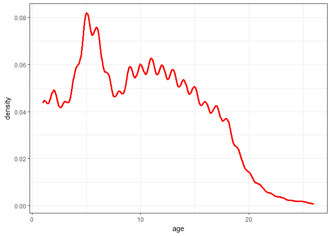

```r
# Now lets do a visual exploration of our new feature
# View distribution of variable
# Most packed around the 5 Year mark
cars %>%
  ggplot(aes(x=age))+geom_line(stat="density", color="red", size=1.2)+theme_bw()
```

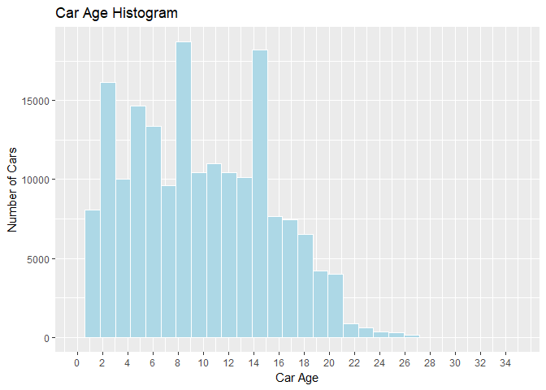

```r
# Histogram for a view from another angle by year
ggplot(aes(cars$age), data=cars) +
  geom_histogram(color='white', fill='lightblue') +
  scale_x_continuous(limit=c(0, 35), breaks=seq(0, 35, 2)) +
  labs(x= 'Car Age', y= 'Number of Cars', title= 'Car Age Histogram')
```

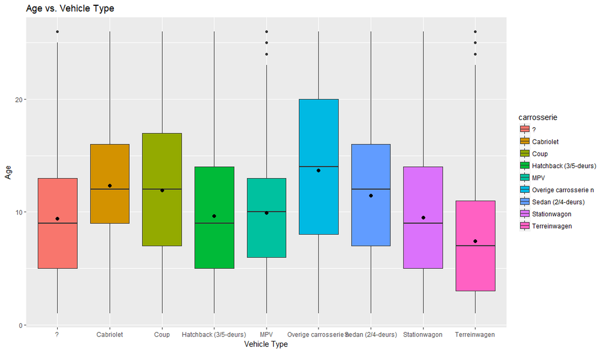

```r
# See if we can unconver anything by segregating by car type
# We have a "?" factor
# overiege have a broad spectrum of ages
ggplot(aes(x= carrosserie, y= age), data=cars) +
  geom_boxplot(fill="lightblue", color='black') +
  geom_boxplot(aes(fill = carrosserie)) +
  stat_summary(fun.y = mean, geom="point", size=2) +
  labs(x= 'Vehicle Type', y= 'Age') +
  ggtitle('Age vs. Vehicle Type')
```

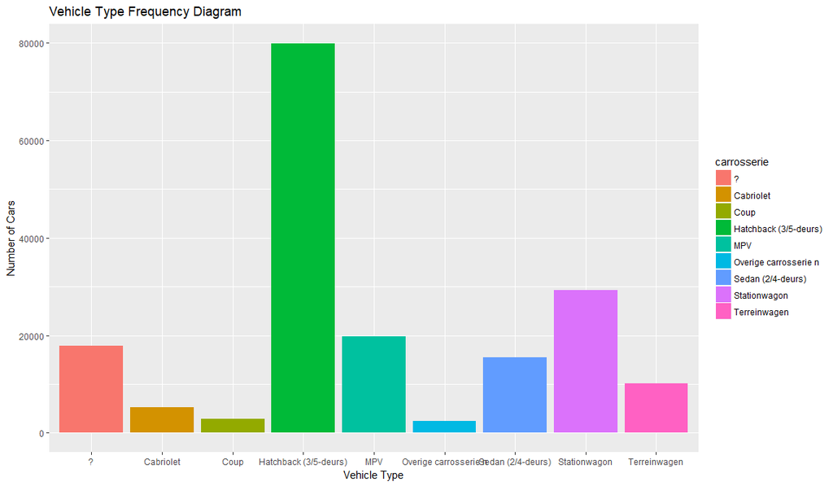

```r
# Examine Car Types
# We have a very high amount of "Hatchbacks" in our dataset
ggplot(cars, aes(x=carrosserie, fill = carrosserie)) +
  geom_bar() +
  labs(x= 'Vehicle Type', y= 'Number of Cars') +
  ggtitle('Vehicle Type Frequency Diagram')
```

```r
  # scale_x_(breaks = seq(0, 4.8, 0.5), minor_breaks = seq(0, 4.8, 0.1))
```

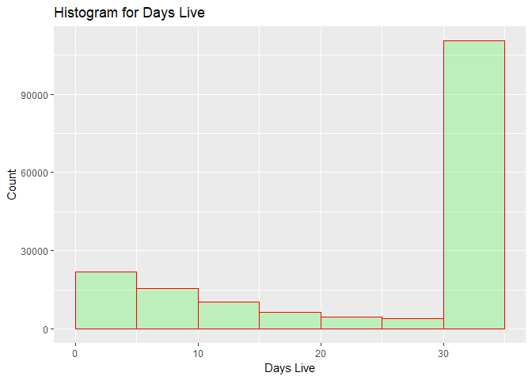

```r
# How long before a car is sold?
# Most cars carry on for the 30+ days
ggplot(data=cars, aes(cars$days_live)) +
  geom_histogram(breaks=seq(0, 35, by = 5),
                 col="red",
                 fill="green",
                 alpha = .2) +
  labs(title="Histogram for Days Live") +
  labs(x="Days Live", y="Count")
```

```r
# create total clicks variable
cars <- cars %>% mutate(total_clicks = (telclicks + webclicks + n_asq +bids))

# create the response variable (label)
cars$clicked       <- ifelse(cars$total_clicks > 0, 1, 0)
cars$clicked       <- as.factor(cars$clicked)
```

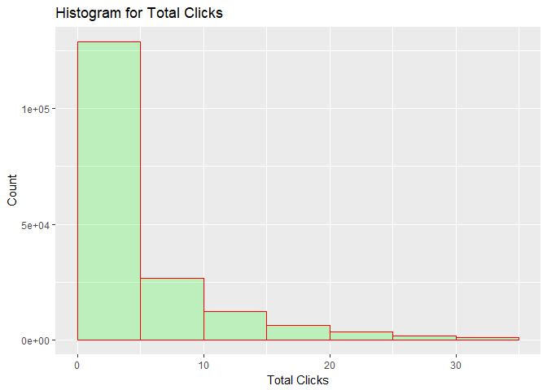

```r
# examine response variable
# as expected, most clicks fall into 0 or 1
ggplot(data=cars, aes(cars$total_clicks)) +
  geom_histogram(breaks=seq(0, 35, by = 5),
                 col="red",
                 fill="green",
                 alpha = .2) +
  labs(title="Histogram for Total Clicks") +
  labs(x="Total Clicks", y="Count")
```

```r
# now that we have our label, lets examine the A/B test results
# create new table with only A/B test results for later analysis
cars_ab <- cars %>% filter(test_group_clean == "A" | test_group_clean == "B")
cars_a <- cars %>% filter(test_group_clean == "A")
cars_b <- cars %>% filter(test_group_clean == "B")

# summary(cars_a)
# summary(cars_b)
# Examining the Data, the only difference between the groups we found was that
# Group B has Higher Mean Price than Group A
t.test(price ~ test_group_clean, data = cars_ab, alternative = "less")
```

```
##
##  Welch Two Sample t-test
##
## data:  price by test_group_clean
## t = -5.4667, df = 3554.2, p-value = 2.451e-08
## alternative hypothesis: true difference in means is less than 0
## 95 percent confidence interval:
##       -Inf -11563.19
## sample estimates:
## mean in group A mean in group B
##        54279.19        70820.88
```

```r
# hypothesis seems to be that price will affect our click rate on ads
# lets test this out, group A has significantly more clicks than group B
t.test(total_clicks ~ test_group_clean, data = cars_ab, alternative= "greater")
```

```
##
##  Welch Two Sample t-test
##
## data:  total_clicks by test_group_clean
## t = 10.986, df = 3108.6, p-value < 2.2e-16
## alternative hypothesis: true difference in means is greater than 0
## 95 percent confidence interval:
##  8.607634      Inf
## sample estimates:
## mean in group A mean in group B
##        25.91237        15.78852
```

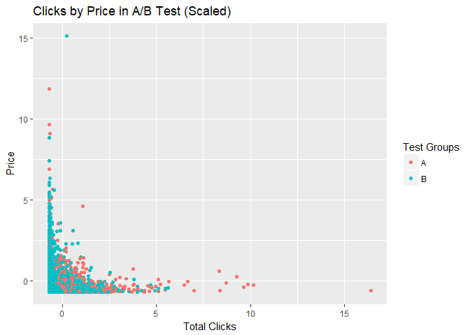

```r
# Looks like the groups may be split up to see impact of clicks by price
# lets visualize what that looks like
ggplot(na.omit(cars_ab), aes(x = scale(total_clicks), y = scale(price), color = test_group_clean)) +
  geom_point() +
  labs(title = "Clicks by Price in A/B Test (Scaled)") +
  labs(color = "Test Groups") +
  labs(x = "Total Clicks", y = "Price")
```

```r
# Calculating the confidence intervals for each group by total clicks now
# Group A
error_tca <- qt(0.90, df=length(cars_a$total_clicks) - 1) * sd(cars_a$total_clicks) / sqrt(length(cars_a$total_clicks))
left_tca <- mean(cars_a$total_clicks) - error_tca
right_tca<- mean(cars_a$total_clicks) + error_tca
left_tca; right_tca
```

```
## [1] 24.92305
```

```
## [1] 26.90169
```

```r
# Group B
error_tcb <- qt(0.90, df=length(cars_b$total_clicks) - 1) * sd(cars_b$total_clicks, na.rm = T) / sqrt(length(cars_b$total_clicks))
left_tcb <- mean(cars_b$total_clicks, na.rm = T) - error_tcb
right_tcb <- mean(cars_b$total_clicks, na.rm = T) + error_tcb
left_tcb; right_tcb
```

```
## [1] 15.14298
```

```
## [1] 16.43407
```

```r
# Calculate Click change based on price in groups
clicks_a <- 25.91237
clicks_b <- 15.78852
clicks_t <- clicks_a + clicks_b
conversion <- clicks_a/clicks_t - clicks_b/clicks_t
rate <- round(conversion * 100, 2)
# Receieved 24% more clicks in Group A on Average
rate
```

```
## [1] 24.28
```

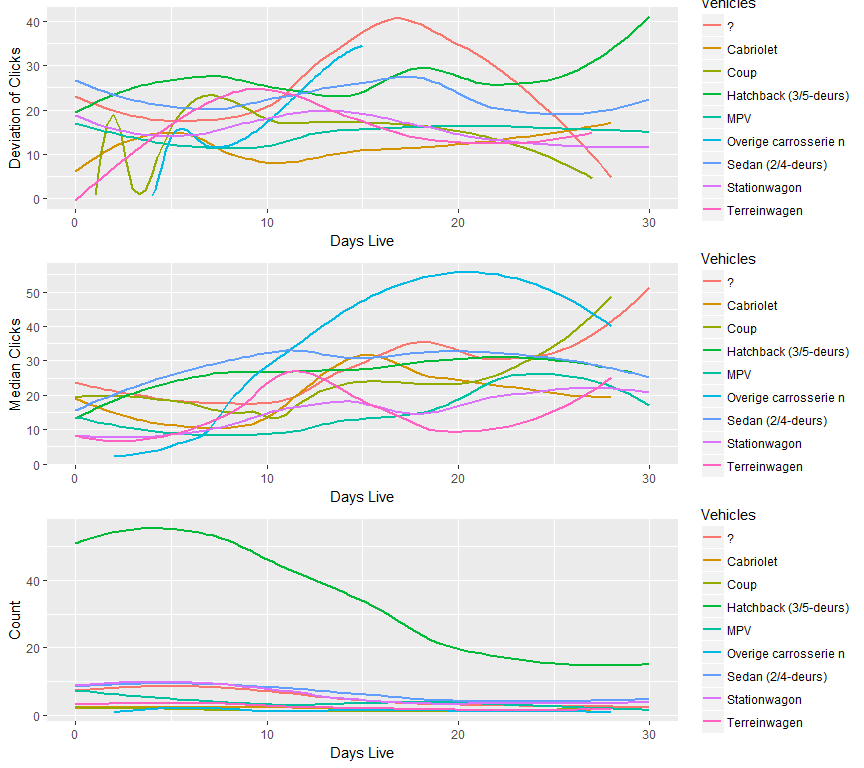

```r
# Examine Three Charts Together
# Standard Deviation of Clicks through Days Live
# Median Clicks through Days Live
# Count of Clicks through Days Live
# Again, high amount of observations are on the Hatback and throughout the month decreases
# The abundance of hatchbacks in the early days will skew our A/B Test results for any inference
days_liveGroup <- group_by(days_live, carrosserie, .data = cars_ab)
days_clicks <- summarise(days_liveGroup,
                         sd_clicks = sd(total_clicks, na.rm = T),
                         median_clicks = median(total_clicks, na.rm = T),
                         count = n())
p1 <- ggplot(days_clicks) +
  geom_smooth(aes(x=days_live, y=sd_clicks, color=carrosserie), se = F) +
  xlim(0,30) +
  labs(color = "Vehicles") +
  labs(x = "Days Live", y = "Deviation of Clicks")
p2 <- ggplot(days_clicks) +
  geom_smooth(aes(x=days_live, y=median_clicks, color=carrosserie), se = F) +
  xlim(0,30) +
  labs(color = "Vehicles") +
  labs(x = "Days Live", y = "Median Clicks")
p3 <- ggplot(days_clicks) +
  geom_smooth(aes(x=days_live, y=count, color=carrosserie), se = F) +
  xlim(0,30) +
  labs(color = "Vehicles") +
  labs(x = "Days Live", y = "Count")
grid.arrange(p1, p2, p3, ncol = 1)
```

```r
# Created an interactive graph so we can play with the data
# lets examine the count data for the entire lifecycle
# Hatchbacks highly popular within test groups
cars_count <- ggplot(days_clicks) +
  geom_smooth(aes(x=days_live, y=count, color=carrosserie), se = F) +
  xlim(0,150) +
  labs(title = "Clicks per Vehicle by Days Live") +
  labs(color = "Vehicles") +
  labs(x = "Days Live", y = "Count")
ggplotly(cars_count)
```

[interactive chart not shown]

```r
# Examine some summary statistics of the Hatcback
# it is below the mean/median price of the group
# it has less power than the average car in the group
# it has less kilometers ran on average even though the age is about the same as group
cars_ab %>% filter(carrosserie == "Hatchback (3/5-deurs)") %>%
  select(photo_cnt, vermogen, price, age, kmstand, test_group_clean) %>%
  summary()
```

```
##    photo_cnt        vermogen          price             age
##  Min.   : 0.00   Min.   :  0.00   Min.   :     0   Min.   : 1.00
##  1st Qu.: 8.00   1st Qu.: 50.00   1st Qu.:  6575   1st Qu.: 7.00
##  Median :11.00   Median : 55.00   Median : 24000   Median :12.00
##  Mean   :12.35   Mean   : 64.38   Mean   : 44457   Mean   :11.42
##  3rd Qu.:17.00   3rd Qu.: 75.00   3rd Qu.: 62200   3rd Qu.:16.00
##  Max.   :24.00   Max.   :294.00   Max.   :537500   Max.   :25.00
##
##     kmstand       test_group_clean
##  Min.   :     0   A      :992
##  1st Qu.: 82232   B      :891
##  Median :140000   Missing:  0
##  Mean   :144082
##  3rd Qu.:195079
##  Max.   :999999
##  NA's   :36
```

```r
cars_ab %>% filter(carrosserie != "Hatchback (3/5-deurs)") %>%
  select(photo_cnt, vermogen, price, age, kmstand, test_group_clean) %>%
  summary()
```

```
##    photo_cnt        vermogen         price              age
##  Min.   : 0.00   Min.   :  0.0   Min.   :      0   Min.   : 1.00
##  1st Qu.: 9.00   1st Qu.: 74.0   1st Qu.:  14500   1st Qu.: 7.00
##  Median :14.00   Median : 92.0   Median :  40000   Median :12.00
##  Mean   :14.32   Mean   :103.4   Mean   :  82140   Mean   :11.31
##  3rd Qu.:20.00   3rd Qu.:120.0   3rd Qu.: 109000   3rd Qu.:15.00
##  Max.   :24.00   Max.   :386.0   Max.   :1460000   Max.   :26.00
##
##     kmstand       test_group_clean
##  Min.   :     0   A      :811
##  1st Qu.:117430   B      :940
##  Median :179874   Missing:  0
##  Mean   :183448
##  3rd Qu.:245516
##  Max.   :824729
##  NA's   :30
```

```r
# New table with more evenly distributed car data
cars_ab_recent <- cars_ab %>% filter(carrosserie != "Hatchback (3/5-deurs)")
t.test(total_clicks ~ test_group_clean, data = cars_ab_recent)
```

```
##
##  Welch Two Sample t-test
##
## data:  total_clicks by test_group_clean
## t = 8.2817, df = 1321, p-value = 2.945e-16
## alternative hypothesis: true difference in means is not equal to 0
## 95 percent confidence interval:
##   7.263049 11.772100
## sample estimates:
## mean in group A mean in group B
##        21.95314        12.43557
```

```r
# Calculate Click change based on price in groups
clicks_ab <- 21.95314
clicks_ba <- 12.43557
clicks_tt <- clicks_ab + clicks_ba
conversion_smooth <- clicks_ab/clicks_tt - clicks_ba/clicks_tt
rate_smooth <- round(conversion_smooth * 100, 2)
# Receieved 28% more clicks in Group A on Average
# Customers in these samples are more likely to click on cheap cars
# Even when we remove the cheap Hatchback as a highly popular option
rate_smooth
```

```
## [1] 27.68
```

```r
# Having concluded our A/B Analysis, lets go back to our main data
# After examining the variables, we found that many had a "?" or "None" field as factors
# so clean some of the missing/dirty data from these features
cars$kleur         <- as.factor(ifelse(cars$kleur == "?",
                                "Other", cars$kleur))
cars$carrosserie   <- as.factor(ifelse(cars$carrosserie == "?",
                                "Other", cars$carrosserie))
cars$aantaldeuren  <- as.factor(ifelse(cars$aantaldeuren == "None",
                                "Other", cars$aantaldeuren))
cars$energielabel  <- as.factor(ifelse(cars$energielabel == "?",
                                "Other", cars$energielabel))
cars$aantalstoelen <- as.factor(as.numeric(cars$aantalstoelen))
cars$aantalstoelen <- as.factor(ifelse(is.na(cars$aantalstoelen),
                                "Other", cars$aantalstoelen))
cars$photo_cnt     <- as.factor(cars$photo_cnt)
cars$emissie       <- as.numeric(cars$emissie)

# Drop out any price that is unrealistic
# €0 for a car, or 100 million for a volvo, etc.
cars$price <- ifelse(cars$price < quantile(cars$price, 0.05, na.rm = T), NA,
              ifelse(cars$price > quantile(cars$price, 0.98, na.rm = T), NA, cars$price))
```

```r
# "Model" alone has no predictive power but combined with the brand it may
# Combine the Brand and Model of Cars
# Now we can drop "Model" as its mostly noise for our algorithm
cars$brand <- str_replace_all(cars$brand, pattern = "[[:punct:]]", "")
cars$brand <- str_replace_all(cars$brand, pattern = "\\s+", " ")
cars$label <- as.factor(paste(cars$brand, cars$model, sep = " "))
cars$label <- str_replace_all(cars$label, pattern = "[[:punct:]]", "")
cars$label <- str_replace_all(cars$label, pattern = "\\s+", " ")

# Let examine our data and see whats popular for our ads
# Format the Cars Labels
cars$label <- as.factor(tolower(cars$label))
all_labels <- str_split(cars$label, " ")

# how many words per label
words_per_label <- sapply(all_labels, length)
```

```r
# table of frequencies
table(words_per_label)
```

```
## words_per_label
##      2      3      4      5      6      7      8      9     10     11
## 163745  17985    848    370     29     21     11     11      6      8
##     12     13     14     15     16     18     19
##      4     10      2      5      4      2      1
```

```r
# to get it as a percent
100 * round(table(words_per_label)/length(words_per_label), 4)
```

```
## words_per_label
##     2     3     4     5     6     7     8     9    10    11    12    13
## 89.45  9.82  0.46  0.20  0.02  0.01  0.01  0.01  0.00  0.00  0.00  0.01
##    14    15    16    18    19
##  0.00  0.00  0.00  0.00  0.00
```

```r
# vector of words in labels
title_words <- unlist(all_labels)
# get unique words
unique_words <- unique(title_words)
num_unique_words <- length(unique(title_words))
# vector to store counts
count_words <- rep(0, num_unique_words)
# count number of occurrences
for (i in 1:num_unique_words) {
count_words[i] = sum(title_words == unique_words[i])
}
# index values in decreasing order
top_30_order <- order(count_words, decreasing = TRUE)[1:30]
# top 30 frequencies
top_30_freqs <- sort(count_words, decreasing = TRUE)[1:30]
# select top 30 words
top_30_words <- unique_words[top_30_order]
```

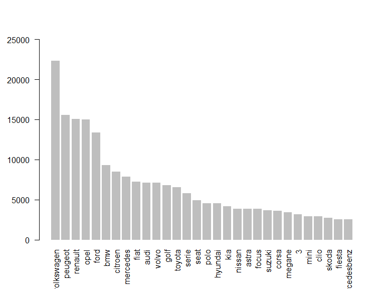

```r
# barplot
# Volkswagen seems to be far ahead of the others
barplot(top_30_freqs, border = NA, names.arg = top_30_words,
        las = 2, ylim = c(0,25000))
```

```r
# Lets see what vehicle type relates to the highest brand
# similar to our AB test results of Hatchback
# the three most popular cars all have Hatchback types
cars %>%
  group_by(brand, carrosserie) %>%
  mutate(count = n()) %>%
  select(brand, carrosserie, count) %>%
  arrange(desc(count)) %>%
  unique() %>%
  head()
```

```
## # A tibble: 6 x 3
## # Groups:   brand, carrosserie [6]
##        brand           carrosserie count
##        <chr>                <fctr> <int>
## 1 VOLKSWAGEN Hatchback (3/5-deurs) 11075
## 2    PEUGEOT Hatchback (3/5-deurs)  8485
## 3       OPEL Hatchback (3/5-deurs)  6815
## 4       FORD Hatchback (3/5-deurs)  6196
## 5    RENAULT Hatchback (3/5-deurs)  5908
## 6       FIAT Hatchback (3/5-deurs)  5194
```

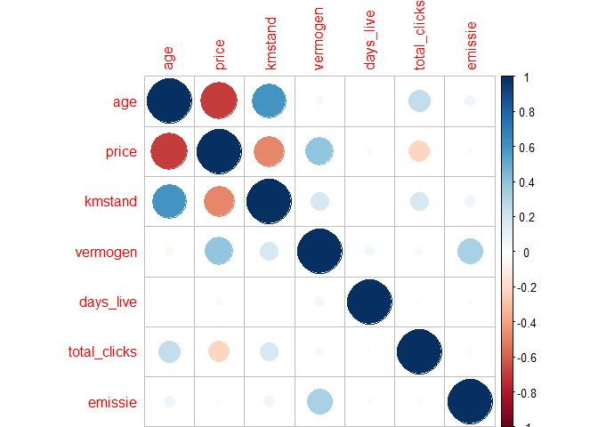

```r
# Any other features worth creating?
# We can bin certain variables if they are worthwhile
# Vermogen can be split into High,Low Power
# Emissiens can be split into High, Low Emission Cars
cars %>% select(age, price, kmstand, vermogen, days_live, total_clicks, emissie) %>%
 cor(use = "complete.obs") %>% corrplot::corrplot()
```

```r
# Features to Drop
# V23 is Empty, Clicks cause leakage, test_group is mostly NA,
# model has too many factors with no value, date was used in Age
# l2 is unknown but mostly noise
table(cars$l2)
```

```
##
##    100    101    103    105    108    110    111    112    113    114
##    245   1948    519    446     81      7   2398   3274     26    513
##    115    117    118    119    122    123    124    125    127    128
##    992    180    118    882      2    100    267    100      2     15
##    129    130    131    132    133    134    135    138    139    140
##    781   2705      2     47    545    607    986   4719     45   3995
##    143    144    146    147    148    150    151    152    153    154
##      6    186   3927    104    280   1908    661    266    162   1242
##    155    157    158    159   2148   2149   2150   2151   2152   2153
##   1870   8072   2038     91     11      3      2     26      2      2
##   2155   2156   2659   2660   2829   2830   2831     92     93     95
##      1      1      5     93      4      9      1    634   2872   5273
##     96     97     98     99   None
##   3687      4     25    470 122577
```

```r
# Select final features, drop ones we won't use or could cause data leakage
features <- cars %>%
  select(- `test group`, - V23, - test_group_clean, - model, - ad_start_dt,
         - src_ad_id, - bouwjaar, - l2, - webclicks, - telclicks, - total_clicks,
         - n_asq, - bids)
str(features)
```

```
## 'data.frame':    183062 obs. of  18 variables:
##  $ kleur           : Factor w/ 10 levels "Beige","Blauw",..: 8 10 8 10 2 9 4 9 9 10 ...
##  $ carrosserie     : Factor w/ 9 levels "Cabriolet","Coup",..: 9 5 3 3 3 3 7 3 3 5 ...
##  $ kmstand         : num  90800 335000 53619 175000 150000 ...
##  $ days_live       : num  100 14 27 3 3 1 1 30 0 1 ...
##  $ photo_cnt       : Factor w/ 25 levels "0","1","2","3",..: 9 9 15 12 6 6 13 5 7 3 ...
##  $ aantaldeuren    : Factor w/ 10 levels "1","2","3","4",..: 6 10 4 4 6 6 5 5 6 6 ...
##  $ emissie         : num  135 89 110 149 142 136 0 156 109 158 ...
##  $ energielabel    : Factor w/ 8 levels "2","3","4","5",..: 2 1 1 3 2 2 8 4 1 3 ...
##  $ brand           : chr  "MITSUBISHI" "VOLKSWAGEN" "FIAT" "PEUGEOT" ...
##  $ vermogen        : num  86 55 51 55 66 44 155 103 50 120 ...
##  $ aantalstoelen   : Factor w/ 17 levels "1","10","11",..: 12 12 11 12 12 12 17 12 11 12 ...
##  $ price           : num  89000 45000 54990 7500 40000 ...
##  $ age             : num  6 6 8 16 10 16 19 12 9 12 ...
##  $ annual_emissions: num  22.5 14.83 13.75 9.31 14.2 ...
##  $ annual_kms      : num  15133 55833 6702 10938 15000 ...
##  $ ageGroup        : Factor w/ 6 levels "(<=3)","(11-15)",..: 5 5 6 3 6 3 3 2 6 2 ...
##  $ clicked         : Factor w/ 2 levels "0","1": 2 2 2 2 2 2 2 2 2 2 ...
##  $ label           : Factor w/ 2332 levels "ackermannfruehauf ",..: 1432 2258 630 1678 1614 683 2014 80 413 181 ...
```

```r
## Examine the Machine Learning Algorithms we will use
# H2O library was used for performance gains
# Algorithms that can effectively handle NA's were used (RF Imputation was used with no difference)
# Algorithms that can effectively scale were used (YeoJohnson was used with no difference)
cars_h2o <- as.h2o(features)

# Split into Training/Validation/Testing sets
splits <- h2o.splitFrame(data = cars_h2o, ratios = c(0.7, 0.15), seed = 1)

train <- splits[[1]]
validate <- splits[[2]]
test <- splits[[3]]

# Define Label and Predictors
response <- "clicked"
predictors <- setdiff(names(train), response)

# Define as Factor since we want to know if its a Click (1) or Not (0)
train[,response] <- as.factor(train[,response])
validate[,response] <- as.factor(validate[,response])
test[,response] <- as.factor(test[,response])
```

```r
# GBM Algorithm with minor human tuning
# One Hot Encoded Variables as it usually improves AUC
gbm_fit <- h2o.gbm(x = predictors,
                   y = response,
                   training_frame = train,
                   model_id = "gbm_fit",
                   validation_frame = validate,
                   ntrees = 500,
                   score_tree_interval = 5,
                   stopping_rounds = 3,
                   stopping_metric = "AUC",
                   stopping_tolerance = 0.0005,
                   categorical_encoding = "OneHotExplicit",
                   seed = 1)
gbm_perf <- h2o.performance(model = gbm_fit,
                            newdata = test)

# Distributed RandomForest
rf_fit <- h2o.randomForest(x = predictors,
                           y = response,
                           training_frame = train,
                           model_id = "rf_fit",
                           seed = 1,
                           nfolds = 5)
rf_perf <- h2o.performance(model = rf_fit,
                           newdata = test)
# Deep Learning with minor human tuning
dl_fit <- h2o.deeplearning(x = predictors,
                           y = response,
                           training_frame = train,
                           model_id = "dl_fit",
                           validation_frame = validate,
                           epochs = 20,
                           hidden = c(10,10),
                           score_interval = 1,
                           stopping_rounds = 3,
                           stopping_metric = "AUC",
                           stopping_tolerance = 0.0005,
                           variable_importances = T,
                           seed = 1)
dl_perf <- h2o.performance(model = dl_fit,
                           newdata = test)

# Naive Bayes, rarely beats the others but its very fast
nb_fit <- h2o.naiveBayes(x = predictors,
                         y = response,
                         training_frame = train,
                         model_id = "nb_fit",
                         laplace = 6,
                         seed = 1)
nb_perf <- h2o.performance(model = nb_fit,
                           newdata = test)

# Generalized Linear Model with Binomial Family
glm_fit <- h2o.glm( x = predictors,
                    y = response,
                    training_frame = train,
                    model_id = "glm_fit",
                    validation_frame = validate,
                    family = "binomial",
                    lambda_search = TRUE)
glm_perf <- h2o.performance(model = glm_fit,
                            newdata = test)
```

```r
# Lets examine the results based on AUC
# RF/DL/GBM performed quite close
# GBM had the best AUC but it was also the slowest
# Area under the Curve
h2o.auc(rf_perf) # 0.7841405
h2o.auc(dl_perf) # 0.7885818
h2o.auc(gbm_perf) # 0.7947957
h2o.auc(nb_perf) #  0.7321336
h2o.auc(glm_perf) # 0.7588988
```

[output not shown]

```r
# Variable Importance
# We see that for GBM the new feature (Age) we created was the most important
# for RF age was the 3rd most important
# Neural Networks are usually not very good at helping us establish relations
gbm_fit@model$variable_importances
rf_fit@model$variable_importances
```

[output not shown]

```r
# Importance of certain variables on our model
# Brand.Tesla and AgeGroup 20+ added positively to our clickrate
glm_fit@model$standardized_coefficient_magnitudes
```

[output not shown]

```r
# Look at scoring history for GBM model
# How long did it take for us to reach optimal accuracy
plot(gbm_fit,
     timestep = "number_of_trees",
     metric = "AUC")

plot(gbm_fit,
     timestep = "number_of_trees",
     metric = "logloss")
```

[output not shown]

```r
# Since GBM was the best performer lets tune it
# Hyper Parameter Tuning
# First Pass
hyper_params = list( max_depth = seq(1,29,2) ) # Since dataqset is small
grid <- h2o.grid(
  hyper_params = hyper_params,
  ## full Cartesian hyper-parameter search
  search_criteria = list(strategy = "Cartesian"),
  algorithm="gbm",
  grid_id="depth_grid",
  x = predictors,
  y = response,
  training_frame = train,
  validation_frame = validate,
  ## here, use "more than enough" trees - we have early stopping
  ntrees = 10000,
  ## since we have learning_rate_annealing, we can afford to start with a bigger learning rate
  learn_rate = 0.05,
  ## learning rate annealing: learning_rate shrinks by 1% after every tree
  learn_rate_annealing = 0.99,
  sample_rate = 0.8,
  col_sample_rate = 0.8,
  seed = 1234,
  ## early stopping once the validation AUC doesn't improve by at least 0.01% for 5 consecutive scoring events
  stopping_rounds = 5,
  stopping_tolerance = 1e-4,
  stopping_metric = "AUC",
  ## score every 10 trees to make early stopping reproducible (it depends on the scoring interval)
  score_tree_interval = 10
)
## sort the grid models by decreasing AUC
sortedGrid <- h2o.getGrid("depth_grid", sort_by="auc", decreasing = TRUE)

## find the range of max_depth for the top 5 models
topDepths = sortedGrid@summary_table$max_depth[1:5]
minDepth = min(as.numeric(topDepths))
maxDepth = max(as.numeric(topDepths))
```

```r
# Now that we know a good range for max_depth,
# we can tune all other parameters in more detail
# Since we don’t know what combinations of hyper-parameters will result in the best model,
# we’ll use random hyper-parameter search
hyper_params = list(
  ## restrict the search to the range of max_depth established above
  max_depth = seq(minDepth,maxDepth,1),
  sample_rate = seq(0.2,1,0.01),
  col_sample_rate = seq(0.2,1,0.01),
  col_sample_rate_per_tree = seq(0.2,1,0.01),
  col_sample_rate_change_per_level = seq(0.9,1.1,0.01),
  min_rows = 2^seq(0,log2(nrow(train))-1,1),
  nbins = 2^seq(4,10,1),
  nbins_cats = 2^seq(4,12,1),
  min_split_improvement = c(0,1e-8,1e-6,1e-4),
  histogram_type = c("UniformAdaptive","QuantilesGlobal","RoundRobin")
)

search_criteria = list(
  ## Random grid search
  strategy = "RandomDiscrete",
  ## limit the runtime to 60 minutes
  max_runtime_secs = 3600,
  ## build no more than 100 models
  max_models = 100,
  seed = 1234,
  ## early stopping once the leaderboard of the top 5 models is converged to 0.1% relative difference
  stopping_rounds = 5,
  stopping_metric = "AUC",
  stopping_tolerance = 1e-3
)

grid <- h2o.grid(
  hyper_params = hyper_params,
  search_criteria = search_criteria,
  algorithm = "gbm",
  grid_id = "final_grid",
  x = predictors,
  y = response,
  training_frame = train,
  validation_frame = validate,
  ntrees = 10000,
  learn_rate = 0.05,
  learn_rate_annealing = 0.99,
  max_runtime_secs = 3600,
  stopping_rounds = 5, stopping_tolerance = 1e-4, stopping_metric = "AUC",
  score_tree_interval = 10,
  nfolds = 5,
  seed = 1234
)

## Sort the grid models by AUC
sortedGrid <- h2o.getGrid("final_grid", sort_by = "auc", decreasing = TRUE)
sortedGrid #0.79839
```

[output not shown]

```r
# Choose Best Model
gbm <- h2o.getModel(sortedGrid@model_ids[[1]])
print(h2o.auc(h2o.performance(gbm, newdata = test))) # 0.7954955
```

[output not shown]

```r
# Keeping the same “best” model,
# we can make test set predictions as follows:
preds <- h2o.predict(gbm, test)
head(preds, 10)
```

[output not shown]

```r
# Final GBM Metrics
gbm@model$validation_metrics@metrics$max_criteria_and_metric_scores
```

[output not shown]

```r
# Save Model and Predictions
h2o.saveModel(gbm, "/tmp/best_model.csv", force=TRUE)
h2o.exportFile(preds, "/tmp/best_preds.csv", force=TRUE)
```